# data-proprecess-nesserary

|  | loan_amnt | funded_amnt | funded_amnt_inv | int_rate | installment | annual_inc | dti | delinq_2yrs | inq_last_6mths | open_acc | pub_rec | revol_bal | revol_util | total_acc | out_prncp | out_prncp_inv | total_pymnt | total_pymnt_inv | total_rec_prncp | total_rec_int | total_rec_late_fee | recoveries | collection_recovery_fee | last_pymnt_amnt | collections_12_mths_ex_med | policy_code | acc_now_delinq | tot_coll_amt | tot_cur_bal | … |
| --- | --- | --- | --- | --- | --- | --- | --- | --- | --- | --- | --- | --- | --- | --- | --- | --- | --- | --- | --- | --- | --- | --- | --- | --- | --- | --- | --- | --- | --- | --- |
| 0 | 7500.00000 | 7500.00000 | 7500.00000 | 7.35000 | 232.79000 | 110000.00000 | 13.12000 | 0.00000 | 2.00000 | 19.00000 | 0.00000 | 23348.00000 | 27.20000 | 27.00000 | 0.00000 | 0.00000 | 7642.28918 | 7642.29000 | 7500.00000 | 142.29000 | 0.00000 | 0.00000 | 0.00000 | 7184.37000 | 0.00000 | 1.00000 | 0.00000 | 0.00000 | 276461.00000 | … |
| 1 | 2300.00000 | 2300.00000 | 2300.00000 | 12.62000 | 77.08000 | 10000.00000 | 21.61000 | 0.00000 | 1.00000 | 4.00000 | 0.00000 | 3911.00000 | 55.10000 | 6.00000 | 2139.64000 | 2139.64000 | 228.83000 | 228.83000 | 160.36000 | 68.47000 | 0.00000 | 0.00000 | 0.00000 | 77.08000 | 0.00000 | 1.00000 | 0.00000 | 0.00000 | 3911.00000 | … |
| 2 | 3000.00000 | 3000.00000 | 3000.00000 | 7.97000 | 93.97000 | 34000.00000 | 12.71000 | 0.00000 | 1.00000 | 10.00000 | 0.00000 | 3443.00000 | 31.00000 | 17.00000 | 2061.10000 | 2061.10000 | 984.62000 | 984.62000 | 938.90000 | 45.72000 | 0.00000 | 0.00000 | 0.00000 | 93.97000 | 0.00000 | 1.00000 | 0.00000 | 0.00000 | 45876.00000 | … |
| 3 | 7500.00000 | 7500.00000 | 7500.00000 | 7.35000 | 232.79000 | 113000.00000 | 21.43000 | 0.00000 | 0.00000 | 7.00000 | 0.00000 | 30569.00000 | 62.90000 | 16.00000 | 6936.00000 | 6936.00000 | 690.71000 | 690.71000 | 564.00000 | 126.71000 | 0.00000 | 0.00000 | 0.00000 | 232.79000 | 0.00000 | 1.00000 | 0.00000 | 0.00000 | 356811.00000 | … |
| 4 | 4200.00000 | 4200.00000 | 4200.00000 | 10.91000 | 137.33000 | 35000.00000 | 31.28000 | 0.00000 | 0.00000 | 23.00000 | 2.00000 | 9594.00000 | 66.20000 | 33.00000 | 3899.85000 | 3899.85000 | 405.63000 | 405.63000 | 300.15000 | 105.48000 | 0.00000 | 0.00000 | 0.00000 | 137.33000 | 0.00000 | 1.00000 | 0.00000 | 154.00000 | 167462.00000 | … |
| 5 | 16000.00000 | 16000.00000 | 16000.00000 | 12.62000 | 360.95000 | 94000.00000 | 25.61000 | 0.00000 | 0.00000 | 9.00000 | 0.00000 | 33752.00000 | 105.80000 | 26.00000 | 15217.01000 | 15217.01000 | 1338.19000 | 1338.19000 | 782.99000 | 555.20000 | 0.00000 | 0.00000 | 0.00000 | 360.95000 | 0.00000 | 1.00000 | 0.00000 | 0.00000 | 234457.00000 | … |
| 6 | 3600.00000 | 3600.00000 | 3600.00000 | 7.35000 | 111.74000 | 45000.00000 | 9.55000 | 0.00000 | 0.00000 | 12.00000 | 0.00000 | 12060.00000 | 11.70000 | 30.00000 | 3329.28000 | 3329.28000 | 331.54000 | 331.54000 | 270.72000 | 60.82000 | 0.00000 | 0.00000 | 0.00000 | 111.74000 | 0.00000 | 1.00000 | 0.00000 | 0.00000 | 115079.00000 | … |
| 7 | 12000.00000 | 12000.00000 | 12000.00000 | 30.65000 | 393.05000 | 121111.00000 | 19.90000 | 2.00000 | 0.00000 | 17.00000 | 0.00000 | 26371.00000 | 78.00000 | 40.00000 | 11733.65000 | 11733.65000 | 1148.51000 | 1148.51000 | 266.35000 | 882.16000 | 0.00000 | 0.00000 | 0.00000 | 393.05000 | 0.00000 | 1.00000 | 0.00000 | 314.00000 | 81349.00000 | … |
| 8 | 7000.00000 | 7000.00000 | 7000.00000 | 7.35000 | 217.27000 | 122000.00000 | 19.22000 | 0.00000 | 1.00000 | 8.00000 | 0.00000 | 20055.00000 | 79.00000 | 12.00000 | 6295.98000 | 6295.98000 | 847.64000 | 847.64000 | 704.02000 | 143.62000 | 0.00000 | 0.00000 | 0.00000 | 217.27000 | 0.00000 | 1.00000 | 0.00000 | 0.00000 | 330539.00000 | … |
| 9 | 12000.00000 | 12000.00000 | 12000.00000 | 14.08000 | 279.72000 | 50000.00000 | 32.49000 | 0.00000 | 0.00000 | 9.00000 | 0.00000 | 13155.00000 | 44.90000 | 18.00000 | 11578.33000 | 11578.33000 | 815.69000 | 815.69000 | 421.67000 | 394.02000 | 0.00000 | 0.00000 | 0.00000 | 279.72000 | 0.00000 | 1.00000 | 0.00000 | 0.00000 | 46483.00000 | … |
| 10 | 5000.00000 | 5000.00000 | 5000.00000 | 7.35000 | 155.19000 | 60000.00000 | 15.76000 | 0.00000 | 1.00000 | 12.00000 | 0.00000 | 3697.00000 | 13.20000 | 25.00000 | 4624.00000 | 4624.00000 | 462.52000 | 462.52000 | 376.00000 | 86.52000 | 0.00000 | 0.00000 | 0.00000 | 155.19000 | 0.00000 | 1.00000 | 0.00000 | 0.00000 | 113100.00000 | … |
| 11 | 12000.00000 | 12000.00000 | 12000.00000 | 15.05000 | 285.80000 | 69800.00000 | 31.43000 | 0.00000 | 1.00000 | 10.00000 | 0.00000 | 15227.00000 | 79.70000 | 12.00000 | 11448.53000 | 11448.53000 | 1052.91000 | 1052.91000 | 551.47000 | 501.44000 | 0.00000 | 0.00000 | 0.00000 | 285.80000 | 0.00000 | 1.00000 | 0.00000 | 0.00000 | 51126.00000 | … |
| 12 | 13000.00000 | 13000.00000 | 13000.00000 | 11.99000 | 431.73000 | 85000.00000 | 6.79000 | 1.00000 | 0.00000 | 5.00000 | 0.00000 | 6866.00000 | 88.00000 | 24.00000 | 12085.41000 | 12085.41000 | 1273.54000 | 1273.54000 | 914.59000 | 358.95000 | 0.00000 | 0.00000 | 0.00000 | 431.73000 | 0.00000 | 1.00000 | 0.00000 | 0.00000 | 15332.00000 | … |
| 13 | 6025.00000 | 6025.00000 | 6025.00000 | 15.05000 | 209.01000 | 46350.00000 | 8.88000 | 0.00000 | 0.00000 | 11.00000 | 0.00000 | 12425.00000 | 44.90000 | 27.00000 | 5619.62000 | 5619.62000 | 614.44000 | 614.44000 | 405.38000 | 209.06000 | 0.00000 | 0.00000 | 0.00000 | 209.01000 | 0.00000 | 1.00000 | 0.00000 | 0.00000 | 121311.00000 | … |
| 14 | 6000.00000 | 6000.00000 | 6000.00000 | 10.42000 | 194.79000 | 37107.19000 | 30.63000 | 0.00000 | 0.00000 | 10.00000 | 1.00000 | 9332.00000 | 59.10000 | 28.00000 | 5568.20000 | 5568.20000 | 575.69000 | 575.69000 | 431.80000 | 143.89000 | 0.00000 | 0.00000 | 0.00000 | 194.79000 | 0.00000 | 1.00000 | 0.00000 | 275.00000 | 107517.00000 | … |
| 15 | 20400.00000 | 20400.00000 | 20400.00000 | 9.44000 | 652.91000 | 44000.00000 | 27.06000 | 0.00000 | 1.00000 | 15.00000 | 0.00000 | 8769.00000 | 18.70000 | 19.00000 | 18911.06000 | 18911.06000 | 1931.98000 | 1931.98000 | 1488.94000 | 443.04000 | 0.00000 | 0.00000 | 0.00000 | 652.91000 | 0.00000 | 1.00000 | 0.00000 | 0.00000 | 62335.00000 | … |
| 16 | 12000.00000 | 12000.00000 | 12000.00000 | 9.44000 | 384.06000 | 70000.00000 | 18.34000 | 0.00000 | 0.00000 | 14.00000 | 1.00000 | 15025.00000 | 58.20000 | 30.00000 | 11124.17000 | 11124.17000 | 1136.45000 | 1136.45000 | 875.83000 | 260.62000 | 0.00000 | 0.00000 | 0.00000 | 384.06000 | 0.00000 | 1.00000 | 0.00000 | 0.00000 | 211227.00000 | … |
| 17 | 11575.00000 | 11575.00000 | 11575.00000 | 7.35000 | 359.26000 | 153000.00000 | 16.99000 | 0.00000 | 0.00000 | 20.00000 | 1.00000 | 8550.00000 | 22.70000 | 46.00000 | 0.00000 | 0.00000 | 11707.81624 | 11707.82000 | 11575.00000 | 132.82000 | 0.00000 | 0.00000 | 0.00000 | 11360.38000 | 0.00000 | 1.00000 | 0.00000 | 0.00000 | 442731.00000 | … |
| 18 | 10000.00000 | 10000.00000 | 10000.00000 | 7.21000 | 309.74000 | 145000.00000 | 6.58000 | 0.00000 | 2.00000 | 12.00000 | 0.00000 | 18633.00000 | 32.70000 | 59.00000 | 9246.52000 | 9246.52000 | 919.21000 | 919.21000 | 753.48000 | 165.73000 | 0.00000 | 0.00000 | 0.00000 | 309.74000 | 0.00000 | 1.00000 | 0.00000 | 0.00000 | 278599.00000 | … |
| 19 | 26000.00000 | 26000.00000 | 26000.00000 | 9.93000 | 838.10000 | 57900.00000 | 12.19000 | 0.00000 | 0.00000 | 7.00000 | 1.00000 | 6857.00000 | 12.40000 | 10.00000 | 24115.64000 | 24115.64000 | 2478.44000 | 2478.44000 | 1884.36000 | 594.08000 | 0.00000 | 0.00000 | 0.00000 | 838.10000 | 0.00000 | 1.00000 | 0.00000 | 0.00000 | 41031.00000 | … |
| 20 | 20000.00000 | 20000.00000 | 20000.00000 | 10.91000 | 653.93000 | 85000.00000 | 20.82000 | 0.00000 | 0.00000 | 15.00000 | 0.00000 | 30759.00000 | 17.80000 | 30.00000 | 18570.79000 | 18570.79000 | 1931.48000 | 1931.48000 | 1429.21000 | 502.27000 | 0.00000 | 0.00000 | 0.00000 | 653.93000 | 0.00000 | 1.00000 | 0.00000 | 0.00000 | 307635.00000 | … |
| 21 | 8000.00000 | 8000.00000 | 8000.00000 | 14.08000 | 273.74000 | 120000.00000 | 31.58000 | 0.00000 | 0.00000 | 16.00000 | 0.00000 | 36658.00000 | 86.70000 | 28.00000 | 7454.02000 | 7454.02000 | 805.58000 | 805.58000 | 545.98000 | 259.60000 | 0.00000 | 0.00000 | 0.00000 | 273.74000 | 0.00000 | 1.00000 | 0.00000 | 0.00000 | 87827.00000 | … |
| 22 | 25000.00000 | 25000.00000 | 25000.00000 | 15.05000 | 595.41000 | 60000.00000 | 15.98000 | 0.00000 | 0.00000 | 13.00000 | 0.00000 | 26947.00000 | 73.20000 | 18.00000 | 23825.85000 | 23825.85000 | 2208.07000 | 2208.07000 | 1174.15000 | 1033.92000 | 0.00000 | 0.00000 | 0.00000 | 595.41000 | 0.00000 | 1.00000 | 0.00000 | 0.00000 | 26947.00000 | … |
| 23 | 2000.00000 | 2000.00000 | 2000.00000 | 7.07000 | 61.82000 | 80000.00000 | 12.15000 | 0.00000 | 1.00000 | 9.00000 | 0.00000 | 38.00000 | 0.30000 | 12.00000 | 1849.00000 | 1849.00000 | 183.50000 | 183.50000 | 151.00000 | 32.50000 | 0.00000 | 0.00000 | 0.00000 | 61.82000 | 0.00000 | 1.00000 | 0.00000 | 0.00000 | 17761.00000 | … |
| 24 | 18950.00000 | 18950.00000 | 18950.00000 | 21.45000 | 517.47000 | 130000.00000 | 31.39000 | 0.00000 | 2.00000 | 12.00000 | 0.00000 | 329271.00000 | 98.00000 | 17.00000 | 18404.14000 | 18404.14000 | 1495.95000 | 1495.95000 | 545.86000 | 950.09000 | 0.00000 | 0.00000 | 0.00000 | 517.47000 | 0.00000 | 1.00000 | 0.00000 | 0.00000 | 1354320.00000 | … |
| 25 | 5800.00000 | 5800.00000 | 5800.00000 | 12.62000 | 194.37000 | 43000.00000 | 27.41000 | 0.00000 | 0.00000 | 11.00000 | 0.00000 | 5710.00000 | 32.30000 | 16.00000 | 5258.03000 | 5258.03000 | 739.50000 | 739.50000 | 541.97000 | 197.53000 | 0.00000 | 0.00000 | 0.00000 | 194.37000 | 0.00000 | 1.00000 | 0.00000 | 83.00000 | 163698.00000 | … |
| 26 | 9600.00000 | 9600.00000 | 9600.00000 | 7.97000 | 300.70000 | 140000.00000 | 18.34000 | 0.00000 | 0.00000 | 16.00000 | 0.00000 | 11808.00000 | 48.60000 | 44.00000 | 8884.45000 | 8884.45000 | 891.47000 | 891.47000 | 715.55000 | 175.92000 | 0.00000 | 0.00000 | 0.00000 | 300.70000 | 0.00000 | 1.00000 | 0.00000 | 814.00000 | 339082.00000 | … |
| 27 | 2400.00000 | 2400.00000 | 2400.00000 | 11.99000 | 79.71000 | 62420.00000 | 16.19000 | 1.00000 | 0.00000 | 16.00000 | 0.00000 | 8930.00000 | 66.60000 | 35.00000 | 2231.13000 | 2231.13000 | 235.13000 | 235.13000 | 168.87000 | 66.26000 | 0.00000 | 0.00000 | 0.00000 | 79.71000 | 0.00000 | 1.00000 | 0.00000 | 0.00000 | 64426.00000 | … |
| 28 | 20000.00000 | 20000.00000 | 20000.00000 | 9.44000 | 640.10000 | 70000.00000 | 25.61000 | 2.00000 | 0.00000 | 8.00000 | 0.00000 | 20589.00000 | 81.70000 | 14.00000 | 18540.28000 | 18540.28000 | 1894.08000 | 1894.08000 | 1459.72000 | 434.36000 | 0.00000 | 0.00000 | 0.00000 | 640.10000 | 0.00000 | 1.00000 | 0.00000 | 0.00000 | 37895.00000 | … |
| 29 | 15000.00000 | 15000.00000 | 15000.00000 | 7.97000 | 469.84000 | 102000.00000 | 11.20000 | 0.00000 | 0.00000 | 14.00000 | 0.00000 | 14460.00000 | 28.90000 | 26.00000 | 13881.96000 | 13881.96000 | 1392.92000 | 1392.92000 | 1118.04000 | 274.88000 | 0.00000 | 0.00000 | 0.00000 | 469.84000 | 0.00000 | 1.00000 | 0.00000 | 0.00000 | 279860.00000 | … |
| ... | ... | ... | ... | ... | ... | ... | ... | ... | ... | ... | ... | ... | ... | ... | ... | ... | ... | ... | ... | ... | ... | ... | ... | ... | ... | ... | ... | ... | ... | … |
| 105423 | 25000.00000 | 25000.00000 | 25000.00000 | 16.99000 | 621.18000 | 141000.00000 | 21.23000 | 0.00000 | 0.00000 | 11.00000 | 0.00000 | 18147.00000 | 85.20000 | 19.00000 | 23338.84000 | 23338.84000 | 3703.48000 | 3703.48000 | 1661.16000 | 2042.32000 | 0.00000 | 0.00000 | 0.00000 | 621.18000 | 0.00000 | 1.00000 | 0.00000 | 0.00000 | 519191.00000 | … |
| 105424 | 6000.00000 | 6000.00000 | 6000.00000 | 17.99000 | 216.89000 | 49000.00000 | 25.32000 | 1.00000 | 2.00000 | 12.00000 | 0.00000 | 15972.00000 | 95.10000 | 22.00000 | 5209.24000 | 5209.24000 | 1295.34000 | 1295.34000 | 790.76000 | 504.58000 | 0.00000 | 0.00000 | 0.00000 | 216.89000 | 0.00000 | 1.00000 | 0.00000 | 0.00000 | 200081.00000 | … |
| 105425 | 13000.00000 | 13000.00000 | 13000.00000 | 25.49000 | 385.32000 | 50000.00000 | 28.01000 | 0.00000 | 1.00000 | 7.00000 | 0.00000 | 13544.00000 | 70.50000 | 17.00000 | 12309.14000 | 12309.14000 | 2293.51000 | 2293.51000 | 690.86000 | 1602.65000 | 0.00000 | 0.00000 | 0.00000 | 385.32000 | 0.00000 | 1.00000 | 0.00000 | 0.00000 | 29656.00000 | … |
| 105426 | 14000.00000 | 14000.00000 | 14000.00000 | 17.99000 | 506.07000 | 35000.00000 | 30.28000 | 0.00000 | 1.00000 | 10.00000 | 0.00000 | 9870.00000 | 45.90000 | 12.00000 | 12154.93000 | 12154.93000 | 3022.43000 | 3022.43000 | 1845.07000 | 1177.36000 | 0.00000 | 0.00000 | 0.00000 | 506.07000 | 0.00000 | 1.00000 | 0.00000 | 0.00000 | 32695.00000 | … |
| 105427 | 25275.00000 | 25275.00000 | 25275.00000 | 28.69000 | 797.52000 | 98000.00000 | 26.50000 | 0.00000 | 0.00000 | 15.00000 | 1.00000 | 23099.00000 | 72.00000 | 32.00000 | 0.00000 | 0.00000 | 27664.95479 | 27664.95000 | 25275.00000 | 2389.95000 | 0.00000 | 0.00000 | 0.00000 | 191.70000 | 0.00000 | 1.00000 | 0.00000 | 0.00000 | 448265.00000 | … |
| 105428 | 26000.00000 | 26000.00000 | 26000.00000 | 12.74000 | 588.13000 | 100000.00000 | 25.48000 | 3.00000 | 1.00000 | 14.00000 | 0.00000 | 60012.00000 | 60.60000 | 31.00000 | 24077.01000 | 24077.01000 | 3510.38000 | 3510.38000 | 1922.99000 | 1587.39000 | 0.00000 | 0.00000 | 0.00000 | 588.13000 | 0.00000 | 1.00000 | 0.00000 | 0.00000 | 283430.00000 | … |
| 105429 | 15000.00000 | 15000.00000 | 15000.00000 | 16.99000 | 372.71000 | 82360.00000 | 30.68000 | 0.00000 | 1.00000 | 16.00000 | 0.00000 | 39174.00000 | 66.30000 | 41.00000 | 14003.29000 | 14003.29000 | 2222.10000 | 2222.10000 | 996.71000 | 1225.39000 | 0.00000 | 0.00000 | 0.00000 | 372.71000 | 0.00000 | 1.00000 | 0.00000 | 0.00000 | 139996.00000 | … |
| 105430 | 13600.00000 | 13600.00000 | 13600.00000 | 18.99000 | 352.72000 | 40000.00000 | 27.12000 | 0.00000 | 1.00000 | 11.00000 | 0.00000 | 17927.00000 | 46.90000 | 18.00000 | 12741.66000 | 12741.66000 | 2166.54000 | 2166.54000 | 858.34000 | 1308.20000 | 0.00000 | 0.00000 | 0.00000 | 352.72000 | 0.00000 | 1.00000 | 0.00000 | 0.00000 | 29387.00000 | … |
| 105431 | 24500.00000 | 24500.00000 | 24500.00000 | 22.74000 | 687.02000 | 59716.00000 | 30.65000 | 0.00000 | 1.00000 | 15.00000 | 0.00000 | 38176.00000 | 66.00000 | 60.00000 | 23098.59000 | 23098.59000 | 3982.84000 | 3982.84000 | 1401.41000 | 2581.43000 | 0.00000 | 0.00000 | 0.00000 | 687.02000 | 0.00000 | 1.00000 | 0.00000 | 0.00000 | 257822.00000 | … |
| 105432 | 28000.00000 | 28000.00000 | 28000.00000 | 16.99000 | 695.73000 | 70000.00000 | 10.01000 | 0.00000 | 0.00000 | 13.00000 | 0.00000 | 7861.00000 | 38.90000 | 23.00000 | 26139.44000 | 26139.44000 | 4147.95000 | 4147.95000 | 1860.56000 | 2287.39000 | 0.00000 | 0.00000 | 0.00000 | 695.73000 | 0.00000 | 1.00000 | 0.00000 | 0.00000 | 25732.00000 | … |
| 105433 | 19200.00000 | 19200.00000 | 19200.00000 | 12.74000 | 434.31000 | 70000.00000 | 25.10000 | 3.00000 | 0.00000 | 12.00000 | 0.00000 | 18542.00000 | 83.50000 | 26.00000 | 17779.95000 | 17779.95000 | 2592.27000 | 2592.27000 | 1420.05000 | 1172.22000 | 0.00000 | 0.00000 | 0.00000 | 434.31000 | 0.00000 | 1.00000 | 0.00000 | 0.00000 | 162543.00000 | … |
| 105434 | 3675.00000 | 3675.00000 | 3675.00000 | 7.99000 | 115.15000 | 45000.00000 | 17.04000 | 0.00000 | 1.00000 | 16.00000 | 0.00000 | 8020.00000 | 57.00000 | 17.00000 | 3121.94000 | 3121.94000 | 689.27000 | 689.27000 | 553.06000 | 136.21000 | 0.00000 | 0.00000 | 0.00000 | 115.15000 | 0.00000 | 1.00000 | 0.00000 | 0.00000 | 42073.00000 | … |
| 105435 | 30000.00000 | 30000.00000 | 30000.00000 | 12.74000 | 678.61000 | 67000.00000 | 25.44000 | 0.00000 | 0.00000 | 16.00000 | 1.00000 | 27709.00000 | 61.20000 | 21.00000 | 27781.17000 | 27781.17000 | 4050.43000 | 4050.43000 | 2218.83000 | 1831.60000 | 0.00000 | 0.00000 | 0.00000 | 678.61000 | 0.00000 | 1.00000 | 0.00000 | 0.00000 | 50462.00000 | … |
| 105436 | 30000.00000 | 30000.00000 | 30000.00000 | 22.74000 | 841.24000 | 75000.00000 | 29.65000 | 0.00000 | 0.00000 | 15.00000 | 0.00000 | 49062.00000 | 72.00000 | 27.00000 | 28284.05000 | 28284.05000 | 5009.54000 | 5009.54000 | 1715.95000 | 3293.59000 | 0.00000 | 0.00000 | 0.00000 | 841.24000 | 0.00000 | 1.00000 | 0.00000 | 0.00000 | 114059.00000 | … |
| 105437 | 18000.00000 | 18000.00000 | 18000.00000 | 22.74000 | 504.75000 | 65000.00000 | 23.41000 | 0.00000 | 0.00000 | 17.00000 | 1.00000 | 12166.00000 | 24.80000 | 25.00000 | 16970.39000 | 16970.39000 | 3005.76000 | 3005.76000 | 1029.61000 | 1976.15000 | 0.00000 | 0.00000 | 0.00000 | 504.75000 | 0.00000 | 1.00000 | 0.00000 | 1836.00000 | 32149.00000 | … |
| 105438 | 31075.00000 | 31075.00000 | 31075.00000 | 22.74000 | 871.39000 | 65400.00000 | 24.26000 | 1.00000 | 0.00000 | 8.00000 | 0.00000 | 15702.00000 | 94.00000 | 11.00000 | 29297.52000 | 29297.52000 | 5189.08000 | 5189.08000 | 1777.48000 | 3411.60000 | 0.00000 | 0.00000 | 0.00000 | 871.39000 | 0.00000 | 1.00000 | 0.00000 | 0.00000 | 44589.00000 | … |
| 105439 | 1000.00000 | 1000.00000 | 1000.00000 | 14.99000 | 34.67000 | 27000.00000 | 9.56000 | 0.00000 | 1.00000 | 7.00000 | 0.00000 | 5608.00000 | 47.50000 | 26.00000 | 0.00000 | 0.00000 | 1014.91890 | 1014.92000 | 1000.00000 | 14.92000 | 0.00000 | 0.00000 | 0.00000 | 1015.75000 | 0.00000 | 1.00000 | 0.00000 | 0.00000 | 5608.00000 | … |
| 105440 | 30000.00000 | 30000.00000 | 30000.00000 | 12.74000 | 678.61000 | 108000.00000 | 32.32000 | 0.00000 | 0.00000 | 14.00000 | 0.00000 | 41068.00000 | 66.50000 | 45.00000 | 27781.17000 | 27781.17000 | 4050.43000 | 4050.43000 | 2218.83000 | 1831.60000 | 0.00000 | 0.00000 | 0.00000 | 678.61000 | 0.00000 | 1.00000 | 0.00000 | 0.00000 | 377121.00000 | … |
| 105441 | 29400.00000 | 29400.00000 | 29400.00000 | 13.99000 | 683.94000 | 32000.00000 | 70.92000 | 0.00000 | 1.00000 | 16.00000 | 0.00000 | 12264.00000 | 46.10000 | 23.00000 | 27292.29000 | 27292.29000 | 4080.79000 | 4080.79000 | 2107.71000 | 1973.08000 | 0.00000 | 0.00000 | 0.00000 | 683.94000 | 0.00000 | 1.00000 | 0.00000 | 0.00000 | 37295.00000 | … |
| 105442 | 35000.00000 | 35000.00000 | 35000.00000 | 25.49000 | 1037.38000 | 180000.00000 | 10.41000 | 0.00000 | 4.00000 | 14.00000 | 0.00000 | 31233.00000 | 58.00000 | 40.00000 | 33140.12000 | 33140.12000 | 6472.11000 | 6472.11000 | 1859.88000 | 4612.23000 | 0.00000 | 0.00000 | 0.00000 | 1037.38000 | 0.00000 | 1.00000 | 0.00000 | 0.00000 | 893435.00000 | … |
| 105443 | 35000.00000 | 35000.00000 | 35000.00000 | 13.99000 | 814.21000 | 100000.00000 | 8.32000 | 0.00000 | 1.00000 | 9.00000 | 1.00000 | 3162.00000 | 14.20000 | 34.00000 | 32490.85000 | 32490.85000 | 4858.06000 | 4858.06000 | 2509.15000 | 2348.91000 | 0.00000 | 0.00000 | 0.00000 | 814.21000 | 0.00000 | 1.00000 | 0.00000 | 0.00000 | 255668.00000 | … |
| 105444 | 12000.00000 | 12000.00000 | 12000.00000 | 28.69000 | 378.65000 | 64500.00000 | 9.66000 | 0.00000 | 3.00000 | 22.00000 | 1.00000 | 16478.00000 | 51.30000 | 42.00000 | 11415.53000 | 11415.53000 | 2252.77000 | 2252.77000 | 584.47000 | 1668.30000 | 0.00000 | 0.00000 | 0.00000 | 378.65000 | 0.00000 | 1.00000 | 0.00000 | 0.00000 | 243226.00000 | … |
| 105445 | 19200.00000 | 19200.00000 | 19200.00000 | 22.74000 | 538.40000 | 53000.00000 | 24.65000 | 0.00000 | 0.00000 | 19.00000 | 0.00000 | 23058.00000 | 76.90000 | 25.00000 | 18103.17000 | 18103.17000 | 3346.24000 | 3346.24000 | 1096.83000 | 2249.41000 | 0.00000 | 0.00000 | 0.00000 | 538.40000 | 0.00000 | 1.00000 | 0.00000 | 0.00000 | 78156.00000 | … |
| 105446 | 24000.00000 | 24000.00000 | 24000.00000 | 23.99000 | 690.30000 | 107000.00000 | 11.65000 | 3.00000 | 1.00000 | 13.00000 | 2.00000 | 9688.00000 | 24.90000 | 24.00000 | 22672.17000 | 22672.17000 | 4298.33000 | 4298.33000 | 1327.83000 | 2970.50000 | 0.00000 | 0.00000 | 0.00000 | 690.30000 | 1.00000 | 1.00000 | 0.00000 | 0.00000 | 60812.00000 | … |
| 105447 | 10000.00000 | 10000.00000 | 10000.00000 | 7.99000 | 313.32000 | 65000.00000 | 19.55000 | 1.00000 | 0.00000 | 15.00000 | 0.00000 | 9751.00000 | 15.70000 | 27.00000 | 8494.72000 | 8494.72000 | 1875.48000 | 1875.48000 | 1505.28000 | 370.20000 | 0.00000 | 0.00000 | 0.00000 | 313.32000 | 0.00000 | 1.00000 | 0.00000 | 0.00000 | 55863.00000 | … |
| 105448 | 10050.00000 | 10050.00000 | 10050.00000 | 16.99000 | 358.26000 | 37000.00000 | 20.56000 | 0.00000 | 1.00000 | 15.00000 | 0.00000 | 14300.00000 | 47.00000 | 21.00000 | 8707.45000 | 8707.45000 | 2140.07000 | 2140.07000 | 1342.55000 | 797.52000 | 0.00000 | 0.00000 | 0.00000 | 358.26000 | 0.00000 | 1.00000 | 0.00000 | 0.00000 | 14300.00000 | … |
| 105449 | 6000.00000 | 6000.00000 | 6000.00000 | 11.44000 | 197.69000 | 41000.00000 | 19.99000 | 1.00000 | 0.00000 | 9.00000 | 0.00000 | 1356.00000 | 10.10000 | 18.00000 | 5136.71000 | 5136.71000 | 1191.87000 | 1191.87000 | 863.29000 | 328.58000 | 0.00000 | 0.00000 | 0.00000 | 197.69000 | 0.00000 | 1.00000 | 1.00000 | 0.00000 | 26201.00000 | … |
| 105450 | 30000.00000 | 30000.00000 | 30000.00000 | 25.49000 | 889.18000 | 105700.00000 | 27.26000 | 1.00000 | 0.00000 | 12.00000 | 0.00000 | 15252.00000 | 72.60000 | 23.00000 | 0.00000 | 0.00000 | 1236.63000 | 1236.63000 | 251.93000 | 940.24000 | 44.46000 | 0.00000 | 0.00000 | 20.00000 | 0.00000 | 1.00000 | 0.00000 | 0.00000 | 239458.00000 | … |
| 105451 | nan | nan | nan | nan | nan | nan | nan | nan | nan | nan | nan | nan | nan | nan | nan | nan | nan | nan | nan | nan | nan | nan | nan | nan | nan | nan | nan | nan | nan | … |
| 105452 | nan | nan | nan | nan | nan | nan | nan | nan | nan | nan | nan | nan | nan | nan | nan | nan | nan | nan | nan | nan | nan | nan | nan | nan | nan | nan | nan | nan | nan | … |

105453 rows × 78 columns

```python
n
n.drop([105451,105452],inplace=True)
```

```python
n[numcol].tail()
```

|  | loan_amnt | funded_amnt | funded_amnt_inv | int_rate | installment | annual_inc | dti | delinq_2yrs | inq_last_6mths | open_acc | pub_rec | revol_bal | revol_util | total_acc | out_prncp | out_prncp_inv | total_pymnt | total_pymnt_inv | total_rec_prncp | total_rec_int | total_rec_late_fee | recoveries | collection_recovery_fee | last_pymnt_amnt | collections_12_mths_ex_med | policy_code | acc_now_delinq | tot_coll_amt | tot_cur_bal | … |
| --- | --- | --- | --- | --- | --- | --- | --- | --- | --- | --- | --- | --- | --- | --- | --- | --- | --- | --- | --- | --- | --- | --- | --- | --- | --- | --- | --- | --- | --- | --- |
| 105446 | 24000.00000 | 24000.00000 | 24000.00000 | 23.99000 | 690.30000 | 107000.00000 | 11.65000 | 3.00000 | 1.00000 | 13.00000 | 2.00000 | 9688.00000 | 24.90000 | 24.00000 | 22672.17000 | 22672.17000 | 4298.33000 | 4298.33000 | 1327.83000 | 2970.50000 | 0.00000 | 0.00000 | 0.00000 | 690.30000 | 1.00000 | 1.00000 | 0.00000 | 0.00000 | 60812.00000 | … |
| 105447 | 10000.00000 | 10000.00000 | 10000.00000 | 7.99000 | 313.32000 | 65000.00000 | 19.55000 | 1.00000 | 0.00000 | 15.00000 | 0.00000 | 9751.00000 | 15.70000 | 27.00000 | 8494.72000 | 8494.72000 | 1875.48000 | 1875.48000 | 1505.28000 | 370.20000 | 0.00000 | 0.00000 | 0.00000 | 313.32000 | 0.00000 | 1.00000 | 0.00000 | 0.00000 | 55863.00000 | … |
| 105448 | 10050.00000 | 10050.00000 | 10050.00000 | 16.99000 | 358.26000 | 37000.00000 | 20.56000 | 0.00000 | 1.00000 | 15.00000 | 0.00000 | 14300.00000 | 47.00000 | 21.00000 | 8707.45000 | 8707.45000 | 2140.07000 | 2140.07000 | 1342.55000 | 797.52000 | 0.00000 | 0.00000 | 0.00000 | 358.26000 | 0.00000 | 1.00000 | 0.00000 | 0.00000 | 14300.00000 | … |
| 105449 | 6000.00000 | 6000.00000 | 6000.00000 | 11.44000 | 197.69000 | 41000.00000 | 19.99000 | 1.00000 | 0.00000 | 9.00000 | 0.00000 | 1356.00000 | 10.10000 | 18.00000 | 5136.71000 | 5136.71000 | 1191.87000 | 1191.87000 | 863.29000 | 328.58000 | 0.00000 | 0.00000 | 0.00000 | 197.69000 | 0.00000 | 1.00000 | 1.00000 | 0.00000 | 26201.00000 | … |
| 105450 | 30000.00000 | 30000.00000 | 30000.00000 | 25.49000 | 889.18000 | 105700.00000 | 27.26000 | 1.00000 | 0.00000 | 12.00000 | 0.00000 | 15252.00000 | 72.60000 | 23.00000 | 0.00000 | 0.00000 | 1236.63000 | 1236.63000 | 251.93000 | 940.24000 | 44.46000 | 0.00000 | 0.00000 | 20.00000 | 0.00000 | 1.00000 | 0.00000 | 0.00000 | 239458.00000 | … |

```python
from sklearn.preprocessing import Imputer
im=Imputer(missing_values='NaN',strategy='mean',axis=0)  #按列来填充处理
#im=im.fit(n[numcol]),n[numcol]=im.transform(n[numcol])
n[numcol]=im.fit_transform(n[numcol])
##n.loc[:,n.columns.str.contains("home_ownership")].head()
```

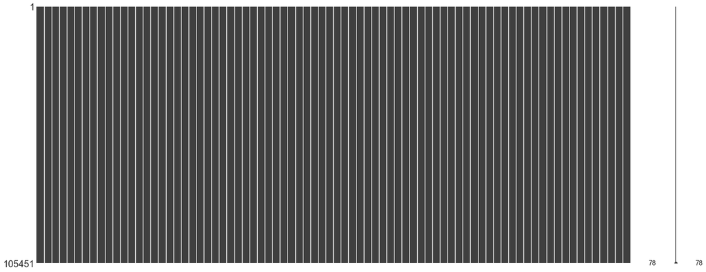

```python
msno.matrix(n[numcol])
```

```python
var=n[objcol].columns     #人工过滤一些特征量
for v in var:
    print('\n特征变量{0}中各值出现的次数'.format(v))
    print(n[v].value_counts())
var
```

```
特征变量term中各值出现的次数
 36 months    77105
 60 months    28346
Name: term, dtype: int64

特征变量grade中各值出现的次数
C    36880
B    31301
A    17898
D    12015
E     4847
F     1725
G      785
Name: grade, dtype: int64

特征变量sub_grade中各值出现的次数
C1    8088
C5    7985
B5    7511
C4    7208
C3    6973
C2    6626
B1    6416
B3    6012
B4    5821
B2    5541
A5    4690
A1    4365
D1    3146
D3    3132
A2    3112
A4    2936
D2    2911
A3    2795
D4    1591
E5    1246
D5    1235
E2    1141
E1     983
E4     788
```

[output cut: 379 more lines]

```

特征变量hardship_flag中各值出现的次数
N    105182
Y       269
Name: hardship_flag, dtype: int64

特征变量disbursement_method中各值出现的次数
Cash         105432
DirectPay        19
Name: disbursement_method, dtype: int64

特征变量debt_settlement_flag中各值出现的次数
N    105443
Y         8
Name: debt_settlement_flag, dtype: int64
```

```
Index(['term', 'grade', 'sub_grade', 'emp_title', 'emp_length',
       'home_ownership', 'verification_status', 'issue_d', 'loan_status',
       'pymnt_plan', 'purpose', 'title', 'zip_code', 'addr_state',
       'earliest_cr_line', 'initial_list_status', 'last_pymnt_d',
       'next_pymnt_d', 'last_credit_pull_d', 'application_type',
       'hardship_flag', 'disbursement_method', 'debt_settlement_flag'],
      dtype='object')
```

```python
drop_list=['sub_grade', 'emp_title',  'title', 'zip_code', 'addr_state',
          'initial_list_status','title',
     'issue_d','last_pymnt_d','next_pymnt_d','last_credit_pull_d',
         'earliest_cr_line']
```

```python
n.drop(drop_list,axis=1,inplace=True)
```

```python
n.select_dtypes(include=['O']).head()
```

|  | term | grade | emp_length | home_ownership | verification_status | loan_status | pymnt_plan | purpose | application_type | hardship_flag | disbursement_method | debt_settlement_flag |
| --- | --- | --- | --- | --- | --- | --- | --- | --- | --- | --- | --- | --- |
| 0 | 36 months | A | 7 years | MORTGAGE | Not Verified | Fully Paid | n | debt_consolidation | Individual | N | Cash | N |
| 1 | 36 months | C | Unknown | OWN | Not Verified | Current | n | credit_card | Individual | N | Cash | N |
| 2 | 36 months | A | 3 years | RENT | Not Verified | Current | n | debt_consolidation | Individual | N | Cash | N |
| 3 | 36 months | A | 10+ years | MORTGAGE | Source Verified | Current | n | debt_consolidation | Individual | N | Cash | N |
| 4 | 36 months | B | 8 years | MORTGAGE | Not Verified | Current | n | other | Individual | N | Cash | N |

不同算法模型需要不同的数据类型来建立。例如逻辑回归只支持数值型的数据，而随机森林通常对字符型和数值型都支持。 上面只是对数据进行了部分预处理，下面开始对特征作进一步的转换

特征衍生：利用现有的特征进行某种组合生成新的特征

```python
n['installment_feat'] = n['installment'] / (n['annual_inc'] / 12)  #根据业务特性直接生成一个新的特征
n.head()
```

|  | loan_amnt | funded_amnt | funded_amnt_inv | term | int_rate | installment | grade | emp_length | home_ownership | annual_inc | verification_status | loan_status | pymnt_plan | purpose | dti | delinq_2yrs | inq_last_6mths | open_acc | pub_rec | revol_bal | revol_util | total_acc | out_prncp | out_prncp_inv | total_pymnt | total_pymnt_inv | total_rec_prncp | total_rec_int | total_rec_late_fee | … |
| --- | --- | --- | --- | --- | --- | --- | --- | --- | --- | --- | --- | --- | --- | --- | --- | --- | --- | --- | --- | --- | --- | --- | --- | --- | --- | --- | --- | --- | --- | --- |
| 0 | 7500.00000 | 7500.00000 | 7500.00000 | 36 months | 7.35000 | 232.79000 | A | 7 years | MORTGAGE | 110000.00000 | Not Verified | Fully Paid | n | debt_consolidation | 13.12000 | 0.00000 | 2.00000 | 19.00000 | 0.00000 | 23348.00000 | 27.20000 | 27.00000 | 0.00000 | 0.00000 | 7642.28918 | 7642.29000 | 7500.00000 | 142.29000 | 0.00000 | … |
| 1 | 2300.00000 | 2300.00000 | 2300.00000 | 36 months | 12.62000 | 77.08000 | C | Unknown | OWN | 10000.00000 | Not Verified | Current | n | credit_card | 21.61000 | 0.00000 | 1.00000 | 4.00000 | 0.00000 | 3911.00000 | 55.10000 | 6.00000 | 2139.64000 | 2139.64000 | 228.83000 | 228.83000 | 160.36000 | 68.47000 | 0.00000 | … |
| 2 | 3000.00000 | 3000.00000 | 3000.00000 | 36 months | 7.97000 | 93.97000 | A | 3 years | RENT | 34000.00000 | Not Verified | Current | n | debt_consolidation | 12.71000 | 0.00000 | 1.00000 | 10.00000 | 0.00000 | 3443.00000 | 31.00000 | 17.00000 | 2061.10000 | 2061.10000 | 984.62000 | 984.62000 | 938.90000 | 45.72000 | 0.00000 | … |
| 3 | 7500.00000 | 7500.00000 | 7500.00000 | 36 months | 7.35000 | 232.79000 | A | 10+ years | MORTGAGE | 113000.00000 | Source Verified | Current | n | debt_consolidation | 21.43000 | 0.00000 | 0.00000 | 7.00000 | 0.00000 | 30569.00000 | 62.90000 | 16.00000 | 6936.00000 | 6936.00000 | 690.71000 | 690.71000 | 564.00000 | 126.71000 | 0.00000 | … |
| 4 | 4200.00000 | 4200.00000 | 4200.00000 | 36 months | 10.91000 | 137.33000 | B | 8 years | MORTGAGE | 35000.00000 | Not Verified | Current | n | other | 31.28000 | 0.00000 | 0.00000 | 23.00000 | 2.00000 | 9594.00000 | 66.20000 | 33.00000 | 3899.85000 | 3899.85000 | 405.63000 | 405.63000 | 300.15000 | 105.48000 | 0.00000 | … |

特征抽象：将数据转换成算法可以理解的数据

```python
def cod(col,coddict):
    colcod=pd.Series(col,copy=True)
    for key,value in coddict.items():
        colcod.replace(key,value,inplace=True)
    return colcod
```

```python
n['loan_status'].value_counts()
```

```
Current               95504
Fully Paid             6430
Late (31-120 days)     1395
In Grace Period        1305
Late (16-30 days)       610
Charged Off             200
Default                   7
Name: loan_status, dtype: int64
```

```python
pd.value_counts(n['loan_status'])
n['loan_status']=cod(n['loan_status'],{'Current':0,'Fully Paid':0,'In Grace Period':1,'Late (31-120 days)':1,
                                       'Late (16-30 days)':1,'Charged Off':1,'Default':1})
print ('\nafter cod:')
pd.value_counts(n['loan_status'])
```

```
after cod:
```

```
0    101934
1      3517
Name: loan_status, dtype: int64
```

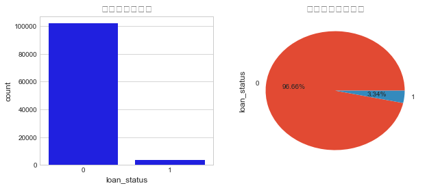

```python
fig,axs=plt.subplots(1,2,figsize=(10,4))
sns.countplot(x='loan_status',data=n,ax=axs[0],color='Blue')
axs[0].set_title('每个借款的频数')
n['loan_status'].value_counts().plot(x=None,y=None,kind='pie',ax=axs[1],autopct='%1.2f%%')
axs[1].set_title('每个借款的百分比')
plt.show()
```

```python
colobjc=n.select_dtypes(include=['O'])
print (colobjc.loc[0])
```

```
term                             36 months
grade                                    A
emp_length                         7 years
home_ownership                    MORTGAGE
verification_status           Not Verified
pymnt_plan                               n
purpose                 debt_consolidation
application_type                Individual
hardship_flag                            N
disbursement_method                   Cash
debt_settlement_flag                     N
Name: 0, dtype: object
```

```python
n['disbursement_method'].value_counts()
```

```
Cash         105432
DirectPay        19
Name: disbursement_method, dtype: int64
```

多值有序变量：顺序数据，多值无序变量：分类数据

```python
#有序特征的映射
n['emp_length'].replace({"10+ years": 10,"9 years": 9,"8 years": 8,"7 years": 7,"6 years": 6,"5 years": 5,
        "4 years": 4,"3 years": 3,"2 years": 2,"1 year": 1,"< 1 year": 0,"n/a": 0},inplace=True)
n['grade'].replace({"A": 1,"B": 2,"C": 3,"D": 4,"E": 5,"F": 6,"G": 7},inplace=True)
n['pymnt_plan'].replace({'n':0,'y':1},inplace=True)
n['hardship_flag'].replace({'N':0,'Y':1},inplace=True)
n['disbursement_method'].replace({'Cash':0,'DirectPay':1},inplace=True)
n['debt_settlement_flag'].replace({'N':0,'Y':1},inplace=True)
#n['installment_feat'].replace({'inf':0},inplace=True)
n['debt_settlement_flag']
```

```
0         0
1         0
2         0
3         0
4         0
5         0
6         0
7         0
8         0
9         0
10        0
11        0
12        0
13        0
14        0
```

[output cut: 47 more lines]

```python
n['emp_length']
```

```
0               7
1         Unknown
2               3
3              10
4               8
5              10
6               1
7              10
8               7
9               9
10              5
11              6
12             10
13              7
14              7
```

[output cut: 47 more lines]

对多值无序变量进行独热编码（one-hot encoding）。 我们使用pandas的get_dummies( )方法创建虚拟特征，虚拟特征的每一列各代表变量属性的一个分类。然后再使用pandas的concat()方法将新建虚拟特征和原数据进行拼接。 get_dummies返回的一组数据是一个稀疏矩阵，但这组数据已经可以带到算法中进行计算。

```python
hotcol=["home_ownership", "verification_status", "application_type","purpose", "term"]
```

```python
hot=pd.get_dummies(n[hotcol])
n=pd.concat([n,hot],axis=1)  #当axis = 1的时候，concat就是行对齐，然后将不同列名称的两张表合并
```

```python
n.loc[:,n.columns.str.contains("home_ownership")].head()   #筛选包含home_ownership的所有变量
```

|  | home_ownership | home_ownership_ANY | home_ownership_MORTGAGE | home_ownership_NONE | home_ownership_OWN | home_ownership_RENT |
| --- | --- | --- | --- | --- | --- | --- |
| 0 | MORTGAGE | 0 | 1 | 0 | 0 | 0 |
| 1 | OWN | 0 | 0 | 0 | 1 | 0 |
| 2 | RENT | 0 | 0 | 0 | 0 | 1 |
| 3 | MORTGAGE | 0 | 1 | 0 | 0 | 0 |
| 4 | MORTGAGE | 0 | 1 | 0 | 0 | 0 |

```python
n=n.drop(hotcol,axis=1)
n.info()
```

```
<class 'pandas.core.frame.DataFrame'>
Int64Index: 105451 entries, 0 to 105450
Columns: 111 entries, loan_amnt to term_ 60 months
dtypes: float64(79), int64(6), object(1), uint8(25)
memory usage: 77.5+ MB
```

```python
n.select_dtypes(include=['O'])
n['emp_length'].value_counts()
```

```
10         35438
2           9914
0           9542
3           8495
1           7034
Unknown     6697
4           6453
5           6382
6           4526
7           3847
9           3828
8           3295
Name: emp_length, dtype: int64
```

```python
n.isin(['Unknown']).sum().sort_values(ascending=False)  #查看所有包含某个值的列
```

```
emp_length                    6697
term_ 60 months                  0
open_rv_24m                      0
policy_code                      0
acc_now_delinq                   0
tot_coll_amt                     0
tot_cur_bal                      0
open_acc_6m                      0
open_act_il                      0
open_il_12m                      0
open_il_24m                      0
mths_since_rcnt_il               0
total_bal_il                     0
open_rv_12m                      0
max_bal_bc                       0
last_pymnt_amnt                  0
all_util                         0
total_rev_hi_lim                 0
inq_fi                           0
total_cu_tl                      0
inq_last_12m                     0
acc_open_past_24mths             0
avg_cur_bal                      0
bc_open_to_buy                   0
bc_util                          0
chargeoff_within_12_mths         0
delinq_amnt                      0
collections_12_mths_ex_med       0
collection_recovery_fee          0
mo_sin_old_rev_tl_op             0
                              ...
purpose_wedding                  0
debt_settlement_flag             0
hardship_flag                    0
mo_sin_rcnt_tl                   0
num_rev_tl_bal_gt_0              0
mort_acc                         0
mths_since_recent_bc             0
mths_since_recent_inq            0
num_accts_ever_120_pd            0
num_actv_bc_tl                   0
num_actv_rev_tl                  0
num_bc_sats                      0
num_bc_tl                        0
num_il_tl                        0
num_op_rev_tl                    0
num_rev_accts                    0
num_sats                         0
total_il_high_credit_limit       0
num_tl_120dpd_2m                 0
num_tl_30dpd                     0
num_tl_90g_dpd_24m               0
num_tl_op_past_12m               0
pct_tl_nvr_dlq                   0
percent_bc_gt_75                 0
pub_rec_bankruptcies             0
tax_liens                        0
tot_hi_cred_lim                  0
total_bal_ex_mort                0
total_bc_limit                   0
loan_amnt                        0
Length: 111, dtype: int64
```

```python
n['emp_length'].replace({'Unknown':0},inplace=True)
#set(n.dtypes)
```

```python
n['emp_length']
```

```
0          7
1          0
2          3
3         10
4          8
5         10
6          1
7         10
8          7
9          9
10         5
11         6
12        10
13         7
14         7
```

[output cut: 47 more lines]

```python
n.info()    #至此所有的数据都换位机器可以计算的数据类型b
```

```
<class 'pandas.core.frame.DataFrame'>
Int64Index: 105451 entries, 0 to 105450
Columns: 111 entries, loan_amnt to term_ 60 months
dtypes: float64(79), int64(7), uint8(25)
memory usage: 77.5 MB
```

```python
n['installment_feat'].value_counts
```

```
<bound method IndexOpsMixin.value_counts of 0        0.02540
1        0.09250
2        0.03317
3        0.02472
4        0.04708
5        0.04608
6        0.02980
7        0.03894
8        0.02137
9        0.06713
10       0.03104
11       0.04913
12       0.06095
13       0.05411
14       0.06299
```

[output cut: 47 more lines]

```python
n.isnull().sum(axis=0).sort_values(ascending=False) #np.isnan(nl).any().value_counts()   这个也能查看数据中有无空值
np.isfinite(n).all() #sort_counts() #判断数据是否为有限值，返回false则表示数据存在无穷数
#np.nan_to_num(n)
n['installment_feat'].value_counts
```

```
<bound method IndexOpsMixin.value_counts of 0        0.02540
1        0.09250
2        0.03317
3        0.02472
4        0.04708
5        0.04608
6        0.02980
7        0.03894
8        0.02137
9        0.06713
10       0.03104
11       0.04913
12       0.06095
13       0.05411
14       0.06299
```

[output cut: 47 more lines]

特征缩放：将变量数据经过处理之后限定到一定的范围之内。特征缩放本质是一个去量纲的过程，同时可以加快算法收敛的速度。目前，将不同变量缩放到相同的区间有两个常用的方法：归一化（normalization）和标准化（standardization）。 标准化的方法保持了异常值所包含的有用信息，并且使得算法受到异常值的影响较小

```python
xcol=n.select_dtypes(include=['int64','float64']).columns
len(xcol)
xxcol=xcol.drop('loan_status')
nl=n
#np.isnan(nl).any().value_counts()   这个也能查看数据中有无空值
#nl.isnull().sum(axis=0).sort_values(ascending=False)     #数据类型确定后（无穷数和空值都有数据类型）
#np.isfinite(nl).all()  #sort_counts() #判断数据是否为有限值，返回false则表示数据存在无穷数
```

```python
nl[xxcol].isnull().sum(axis=0).sort_values(ascending=False)#空值其实没必要查，前面都查过，主要看下是否有无穷数
np.isinf(nl).any()#sum()  #这里一定要注意使用any    #这里搞死我了，以为两个都用all
#print(len(nl.columns))
#np.isfinite(nl).all().sum()
np.isinf(nl['installment_feat']).value_counts()
```

```
False    105377
True         74
Name: installment_feat, dtype: int64
```

```python
where_are_inf = np.isinf(nl['installment_feat'])   #这里将无穷数赋值为0
nl['installment_feat'][where_are_inf]=0
nl['installment_feat'].value_counts()
```

```
0.00000    74
0.07228    70
0.07970    65
0.04818    64
0.03614    58
0.06023    51
0.04981    41
0.02891    37
0.03985    36
0.07792    35
0.05163    34
0.06642    34
0.05782    33
0.05194    31
0.07547    31
0.04337    30
0.09963    30
0.08031    30
0.05594    29
0.06493    29
0.07847    28
0.07736    26
0.05575    26
0.05121    25
0.07449    25
0.06938    25
0.03896    25
0.08057    24
0.08856    24
0.05421    24
           ..
0.18697     1
0.18561     1
0.01653     1
0.01428     1
0.04910     1
0.09143     1
0.16491     1
0.10326     1
0.01182     1
0.08045     1
0.03714     1
0.02895     1
0.10314     1
0.07050     1
0.06762     1
0.03486     1
0.22744     1
0.16144     1
0.09938     1
0.05258     1
0.09226     1
0.03901     1
0.02454     1
0.06191     1
0.09550     1
0.03658     1
0.03599     1
0.15421     1
0.10849     1
0.01128     1
Name: installment_feat, Length: 74491, dtype: int64
```

```python
from sklearn.preprocessing import StandardScaler
s=StandardScaler()  #初始化缩放器
nl[xxcol]=s.fit_transform(nl[xxcol])
nl[xxcol].head()
```

|  | loan_amnt | funded_amnt | funded_amnt_inv | int_rate | installment | grade | emp_length | annual_inc | pymnt_plan | dti | delinq_2yrs | inq_last_6mths | open_acc | pub_rec | revol_bal | revol_util | total_acc | out_prncp | out_prncp_inv | total_pymnt | total_pymnt_inv | total_rec_prncp | total_rec_int | total_rec_late_fee | recoveries | collection_recovery_fee | last_pymnt_amnt | collections_12_mths_ex_med | policy_code | … |
| --- | --- | --- | --- | --- | --- | --- | --- | --- | --- | --- | --- | --- | --- | --- | --- | --- | --- | --- | --- | --- | --- | --- | --- | --- | --- | --- | --- | --- | --- | --- |
| 0 | -0.74789 | -0.74789 | -0.74769 | -1.15104 | -0.72812 | -1.38515 | 0.38433 | 0.43313 | -0.04933 | -0.41493 | -0.37010 | 1.84218 | 1.23776 | -0.39080 | 0.29400 | -0.89959 | 0.27410 | -1.36758 | -1.36757 | 1.18551 | 1.18605 | 1.37255 | -0.90081 | -0.07558 | -0.00308 | -0.00308 | 1.62289 | -0.14138 | 0.00000 | … |
| 1 | -1.29648 | -1.29648 | -1.29644 | -0.12922 | -1.28387 | 0.29542 | -1.40204 | -1.03271 | -0.04933 | 0.18548 | -0.37010 | 0.60623 | -1.35881 | -0.39080 | -0.55234 | 0.25083 | -1.50151 | -1.13216 | -1.13209 | -0.65153 | -0.65152 | -0.50371 | -1.01452 | -0.07558 | -0.00308 | -0.00308 | -0.29584 | -0.14138 | 0.00000 | … |
| 2 | -1.22263 | -1.22263 | -1.22257 | -1.03082 | -1.22359 | -1.38515 | -0.63645 | -0.68091 | -0.04933 | -0.44393 | -0.37010 | 0.60623 | -0.32018 | -0.39080 | -0.57272 | -0.74291 | -0.57143 | -1.14080 | -1.14073 | -0.46424 | -0.46418 | -0.30469 | -1.04956 | -0.07558 | -0.00308 | -0.00308 | -0.29128 | -0.14138 | 0.00000 | … |
| 3 | -0.74789 | -0.74789 | -0.74769 | -1.15104 | -0.72812 | -1.38515 | 1.14992 | 0.47710 | -0.04933 | 0.17275 | -0.37010 | -0.62973 | -0.83950 | -0.39080 | 0.60842 | 0.57246 | -0.65598 | -0.60442 | -0.60422 | -0.53707 | -0.53703 | -0.40052 | -0.92480 | -0.07558 | -0.00308 | -0.00308 | -0.25381 | -0.14138 | 0.00000 | … |
| 4 | -1.09603 | -1.09603 | -1.09594 | -0.46078 | -1.06883 | -0.54487 | 0.63952 | -0.66625 | -0.04933 | 0.86933 | -0.37010 | -0.62973 | 1.93018 | 2.64922 | -0.30489 | 0.70853 | 0.78142 | -0.93849 | -0.93837 | -0.60772 | -0.60770 | -0.46797 | -0.95751 | -0.07558 | -0.00308 | -0.00308 | -0.27958 | -0.14138 | 0.00000 | … |

看下特征选择：从给定的集合中选择出相关特征子集的过程。 优先选择与目标相关性较高的特征，不相关特征包含对于数据挖掘任务完全没用的信息，不相关特征可能会降低分类的准确率，因此为了增强模型的泛化能力，我们需要从原有特征集合中挑选出最佳的部分特征。其次，去除不相关特征可以降低学习的难度（less is more），能够简化分类器的计算，同时帮助了解分类问题的因果关系。 用三种方法组合进行特征选择

```python
xfeature=list(nl.columns)
xfeature.remove('loan_status')
xval=nl[xfeature]     #这里可以看出dataframe索引是列表  df[]与df[[]]显示的内容不一样，后面显示的更加全面
yval=nl['loan_status']
xval.describe().T.head(10)
```

|  | count | mean | std | min | 25% | 50% | 75% | max |
| --- | --- | --- | --- | --- | --- | --- | --- | --- |
| loan_amnt | 105451.00000 | 0.00000 | 1.00000 | -1.43363 | -0.80064 | -0.27314 | 0.57085 | 2.68082 |
| funded_amnt | 105451.00000 | 0.00000 | 1.00000 | -1.43363 | -0.80064 | -0.27314 | 0.57085 | 2.68082 |
| funded_amnt_inv | 105451.00000 | -0.00000 | 1.00000 | -1.43363 | -0.80046 | -0.27281 | 0.57142 | 2.68200 |
| int_rate | 105451.00000 | -0.00000 | 1.00000 | -1.54464 | -0.65079 | -0.12922 | 0.52420 | 3.43259 |
| installment | 105451.00000 | -0.00000 | 1.00000 | -1.45148 | -0.72866 | -0.26917 | 0.52671 | 4.57931 |
| grade | 105451.00000 | -0.00000 | 1.00000 | -1.38515 | -0.54487 | 0.29542 | 0.29542 | 3.65656 |
| emp_length | 105451.00000 | 0.00000 | 1.00000 | -1.40204 | -0.89165 | -0.12606 | 1.14992 | 1.14992 |
| annual_inc | 105451.00000 | -0.00000 | 1.00000 | -1.17930 | -0.47569 | -0.18253 | 0.24257 | 129.28038 |
| pymnt_plan | 105451.00000 | 0.00000 | 1.00000 | -0.04933 | -0.04933 | -0.04933 | -0.04933 | 20.27111 |
| dti | 105451.00000 | -0.00000 | 1.00000 | -1.34277 | -0.47716 | -0.06063 | 0.39481 | 69.30591 |

用递归特征消除法筛选30个与目标变量相关性最强的特征，逐步剔除特征从而达到首次降维

```python
from sklearn.feature_selection import RFE
from sklearn.linear_model import LinearRegression
model=LinearRegression()
rfe=RFE(model,30)
rfe=rfe.fit(xval,yval)    #这里用fit返回的是一个方法，用fit_transform返回的是处理后的数组
rfe.support_
```

```
array([ True,  True,  True,  True,  True,  True, False, False,  True,
       False, False, False, False, False, False, False, False,  True,
        True,  True,  True,  True,  True,  True,  True,  True,  True,
       False, False, False, False, False, False, False, False, False,
       False, False, False,  True, False, False, False, False, False,
       False,  True, False, False, False, False, False, False, False,
       False, False, False, False, False, False, False, False, False,
       False, False, False, False, False, False, False, False, False,
       False, False, False, False, False, False, False, False, False,
        True, False,  True, False, False, False,  True, False, False,
       False, False,  True, False, False, False, False, False, False,
       False, False,  True,  True, False,  True,  True, False,  True,
        True,  True], dtype=bool)
```

```python
rfe.ranking_
```

```
array([ 1,  1,  1,  1,  1,  1, 53, 64,  1, 81, 32, 28, 10, 43,  5, 22,  7,
        1,  1,  1,  1,  1,  1,  1,  1,  1,  1, 50, 70, 34, 67, 60, 75, 63,
       31, 52, 58,  3, 29,  1, 45, 46, 72, 51, 54, 42,  1, 74, 44, 23, 76,
       80, 69, 66, 61, 55, 21, 71, 77, 41, 37, 38, 39, 65,  9, 12,  8, 49,
       11, 36, 35, 33, 30, 73, 24, 78, 79, 62,  4, 40, 13,  1, 56,  1, 68,
       15, 16,  1, 14, 17, 47, 48,  1,  2, 27, 20, 18, 19, 26,  6, 25,  1,
        1, 57,  1,  1, 59,  1,  1,  1])
```

```python
colfilter=xval.columns[rfe.support_]    #通过布尔值选取降维后的特征列
colfilter
```

```
Index(['loan_amnt', 'funded_amnt', 'funded_amnt_inv', 'int_rate',
       'installment', 'grade', 'pymnt_plan', 'out_prncp', 'out_prncp_inv',
       'total_pymnt', 'total_pymnt_inv', 'total_rec_prncp', 'total_rec_int',
       'total_rec_late_fee', 'recoveries', 'collection_recovery_fee',
       'last_pymnt_amnt', 'open_rv_24m', 'acc_open_past_24mths',
       'hardship_flag', 'debt_settlement_flag', 'home_ownership_NONE',
       'verification_status_Verified', 'purpose_medical', 'purpose_moving',
       'purpose_renewable_energy', 'purpose_small_business', 'purpose_wedding',
       'term_ 36 months', 'term_ 60 months'],
      dtype='object')
```

用相关图方法进行进一步的降维

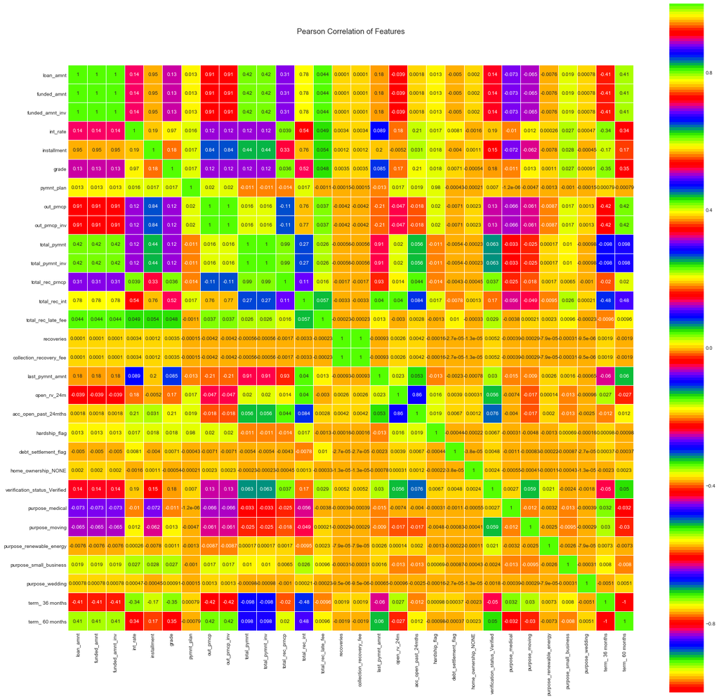

```python
colormap = plt.cm.prism
plt.figure(figsize=(25,25))
plt.title('Pearson Correlation of Features', y=1.05, size=15)
sns.heatmap(xval[colfilter].corr(),linewidths=0.1,vmax=1.0,
            square=True, cmap=colormap, linecolor='white', annot=True)
# linewidths，linecolor划分线的宽度和颜色，annot是否在方格里注释数据，
#vmin, vmax相关度最大值和最小值，此处限制1.0最大，可见图中图谱最大为1.0
```

```python
dropcol=['funded_amnt', 'funded_amnt_inv','installment', 'out_prncp','out_prncp_inv','total_pymnt_inv'
         ,'total_rec_prncp','total_rec_int','term_ 36 months','total_pymnt','int_rate']
```

```python
newcol=colfilter.drop(dropcol)
newcol
```

```
Index(['loan_amnt', 'grade', 'pymnt_plan', 'total_rec_late_fee', 'recoveries',
       'collection_recovery_fee', 'last_pymnt_amnt', 'open_rv_24m',
       'acc_open_past_24mths', 'hardship_flag', 'debt_settlement_flag',
       'home_ownership_NONE', 'verification_status_Verified',
       'purpose_medical', 'purpose_moving', 'purpose_renewable_energy',
       'purpose_small_business', 'purpose_wedding', 'term_ 60 months'],
      dtype='object')
```

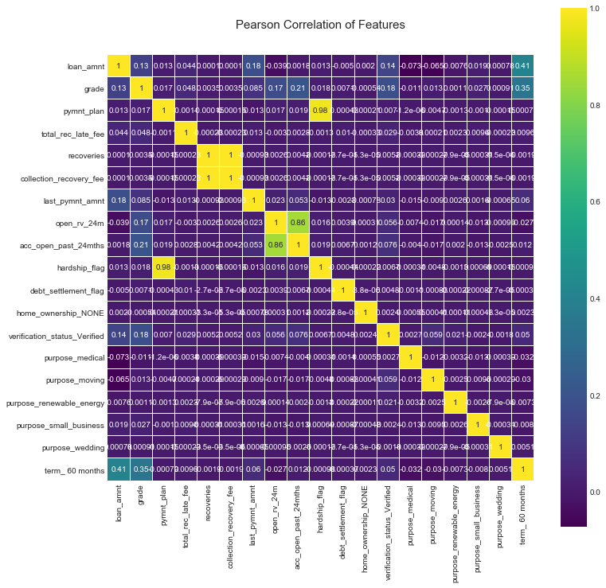

```python
colormap = plt.cm.viridis
plt.figure(figsize=(12,12))
plt.title('Pearson Correlation of Features', y=1.05, size=15)
sns.heatmap(xval[newcol].corr(),linewidths=0.1,vmax=1.0, square=True,cmap=colormap,
            linecolor='white', annot=True)
```

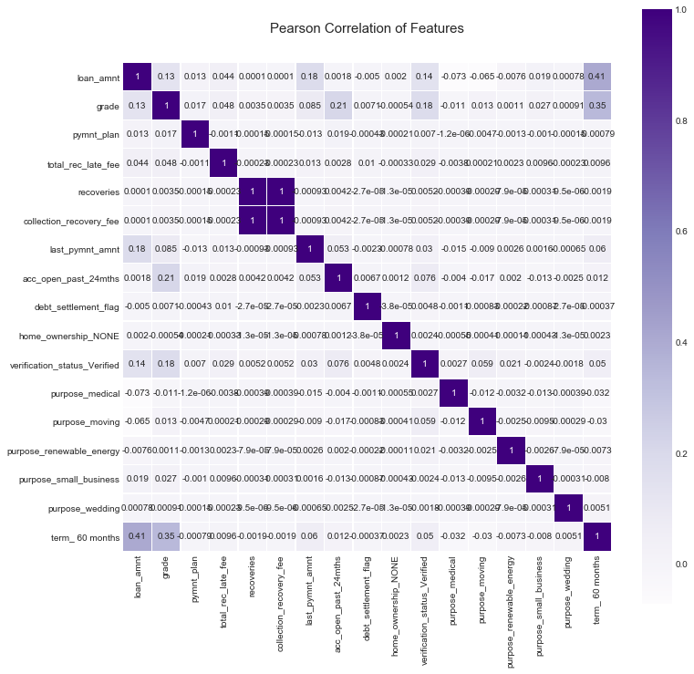

```python
dropcol_1=['hardship_flag','open_rv_24m']
newcol_1=newcol.drop(dropcol_1)
colormap = plt.cm.Purples
plt.figure(figsize=(12,12))
plt.title('Pearson Correlation of Features', y=1.05, size=15)
sns.heatmap(xval[newcol_1].corr(),linewidths=0.1,vmax=1.0, square=True,cmap=colormap,
            linecolor='white', annot=True)
```

```python
len(newcol_1)
```

```
17
```

```python
names=xval[newcol_1].columns
from sklearn.ensemble import RandomForestClassifier
clf=RandomForestClassifier(n_estimators=10,random_state=123)
clf.fit(xval[newcol_1],yval)
names,clf.feature_importances_
for feature in zip(names,clf.feature_importances_):
    print (feature)
```

```
('loan_amnt', 0.19074724070250232)
('grade', 0.031038867790524498)
('pymnt_plan', 0.084996383012424376)
('total_rec_late_fee', 0.042849822445681224)
('recoveries', 0.0)
('collection_recovery_fee', 0.00032801390621589209)
('last_pymnt_amnt', 0.49023726055582451)
('acc_open_past_24mths', 0.135476763706669)
('debt_settlement_flag', 0.0026243574660109372)
('home_ownership_NONE', 3.8685157781204175e-07)
('verification_status_Verified', 0.0057212366823173027)
('purpose_medical', 0.0036194274946496395)
('purpose_moving', 0.0031833791839495197)
('purpose_renewable_energy', 0.0006180903669522395)
('purpose_small_business', 0.0035983025978525394)
('purpose_wedding', 2.9524696087379737e-07)
('term_ 60 months', 0.0049601719898873797)
```

```python
plt.style.use('fivethirtyeight')
plt.rcParams['figure.figsize'] = (12,6)
```

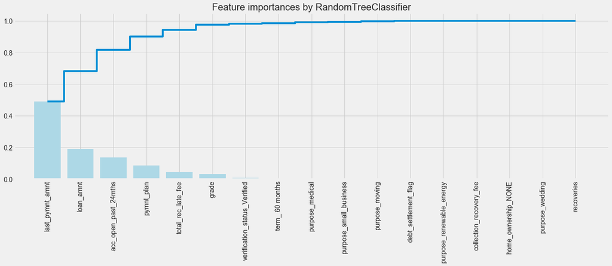

```python
importances = clf.feature_importances_
feat_names = names
indices = np.argsort(importances)[::-1]
fig = plt.figure(figsize=(20,6))
plt.title("Feature importances by RandomTreeClassifier")
plt.bar(range(len(indices)), importances[indices], color='lightblue',  align="center")
plt.step(range(len(indices)), np.cumsum(importances[indices]), where='mid', label='Cumulative')
plt.xticks(range(len(indices)), feat_names[indices], rotation='vertical',fontsize=14)
plt.xlim([-1, len(indices)])
plt.show()
```

以上为特征重要性排序，下面看下模型训练 样本不平衡：1、过采样（oversampling），增加正样本使得正、负样本数目接近，然后再进行学习。2、欠采样（undersampling），去除一些负样本使得正、负样本数目接近，然后再进行学习。 过采样，具体操作使用SMOTE（Synthetic Minority Oversampling Technique），SMOET的基本原理是：采样最邻近算法，计算出每个少数类样本的K个近邻，从K个近邻中随机挑选N个样本进行随机线性插值，构造新的少数样本，同时将新样本与原数据合成，产生新的训练集。

```python
x=xval[newcol_1]
y=yval
nsample=y.shape[0]
y.shape[0]
x.shape
```

```
(105451, 17)
```

```python
n_pos_sample = y[y == 0].shape[0]
n_neg_sample = y[y == 1].shape[0]
print('样本个数：{}; 正样本占{:.2%}; 负样本占{:.2%}'.format(nsample,
                                                   n_pos_sample / nsample,
                                                   n_neg_sample / nsample))
print('特征维数：', x.shape[1])
```

```
样本个数：105451; 正样本占96.66%; 负样本占3.34%
特征维数： 17
```

```python
from imblearn.over_sampling import SMOTE
sm=SMOTE(random_state=222)
x,y=sm.fit_sample(x,y)
print('通过SMOTE方法平衡正负样本后')
nsample=y.shape[0]
n_pos_sample = y[y == 0].shape[0]
n_neg_sample = y[y == 1].shape[0]
print('样本个数：{}; 正样本占{:.2%}; 负样本占{:.2%}'.format(nsample,
                                                   n_pos_sample / nsample,
                                                   n_neg_sample / nsample))
y.shape
```

```
通过SMOTE方法平衡正负样本后
样本个数：203868; 正样本占50.00%; 负样本占50.00%
```

```
(203868,)
```

```python
x.shape
```

```
(203868, 17)
```

```python
from sklearn.linear_model import LogisticRegression
clf1=LogisticRegression()
clf1.fit(x,y)
```

```
LogisticRegression(C=1.0, class_weight=None, dual=False, fit_intercept=True,
          intercept_scaling=1, max_iter=100, multi_class='ovr', n_jobs=1,
          penalty='l2', random_state=None, solver='liblinear', tol=0.0001,
          verbose=0, warm_start=False)
```

```python
predict=clf1.predict(x)
predict
```

```
array([0, 0, 0, ..., 1, 1, 1], dtype=int64)
```

```python
from sklearn.metrics import accuracy_score
print("Test set accuracy score: {:.5f}".format(accuracy_score(predict, y,)))
```

```
Test set accuracy score: 0.67559
```

```python
from sklearn.metrics import confusion_matrix
m=confusion_matrix(y,predict)
m      #混淆矩阵对分类器产生不同类型的正误数量的统计
```

```
array([[75840, 26094],
       [40043, 61891]], dtype=int64)
```

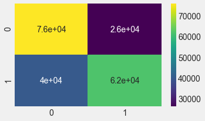

```python
plt.figure(figsize=(5,3))
sns.heatmap(data=m,cmap=plt.cm.viridis,annot=True)
```

```python
from sklearn.metrics import classification_report
print (classification_report(y,predict))
```

```
             precision    recall  f1-score   support

          0       0.65      0.74      0.70    101934
          1       0.70      0.61      0.65    101934

avg / total       0.68      0.68      0.67    203868
```

```python
from sklearn.metrics import roc_auc_score
roc_auc=roc_auc_score(y,predict)
print ('roc曲线下的面积：%.5f'%roc_auc)
```

```
roc曲线下的面积：0.67559
```

下面看模型评估与优化 将数据集划分为训练集和测试集有3种处理方法：1、留出法（hold-out），2、交叉验证法（cross-validation），3、自助法（bootstrapping） 交叉验证法划分数据集，将数据划分为3部分：训练集（training set）、验证集（validation set）和测试集（test set）。让模型在训练集进行学习，在验证集上进行参数调优，最后使用测试集数据评估模型的性能。

```python
from sklearn.model_selection import GridSearchCV
from sklearn.model_selection import train_test_split
```

```python
xtrain,xtest,ytrain,ytest=train_test_split(x,y,test_size=0.3,random_state=0)
#random_state = 0 给定一个初始状态，每次切分的数据都一样
param_grid={'penalty':['l1','l2'],'C':[0.01,0.1,1,10,100,1000]}
```

```python
grid_search=GridSearchCV(LogisticRegression(),param_grid,cv=10)   #LogisticRegression()这里必须加括号传入实列
ch=grid_search.fit(xtrain,ytrain)            #这里注意逻辑斯提回归与线性回归的应用区别，这里搞混了，导致参数出错
```

```python
result=pd.DataFrame(ch.cv_results_)
best=np.argmax(result.mean_test_score.values)  #np.argmax返回沿轴axis=0(列)最大值的索引
```

[output not shown]

```python
result['mean_train_score']
```

```
0    0.67402
1    0.67390
2    0.67434
3    0.67471
4    0.67476
5    0.67483
6    0.67482
7    0.67486
8    0.67484
9    0.67486
10   0.67484
11   0.67485
Name: mean_train_score, dtype: float64
```

```
Best parameters: {'C': 1, 'penalty': 'l1'}
Best cross-validation score: 0.67489
```

```
[Text(0,0,"{'C': 0.01, 'penalty': 'l1'}"),
 Text(0,0,"{'C': 0.01, 'penalty': 'l2'}"),
 Text(0,0,"{'C': 0.1, 'penalty': 'l1'}"),
 Text(0,0,"{'C': 0.1, 'penalty': 'l2'}"),
 Text(0,0,"{'C': 1, 'penalty': 'l1'}"),
 Text(0,0,"{'C': 1, 'penalty': 'l2'}"),
 Text(0,0,"{'C': 10, 'penalty': 'l1'}"),
 Text(0,0,"{'C': 10, 'penalty': 'l2'}"),
 Text(0,0,"{'C': 100, 'penalty': 'l1'}"),
 Text(0,0,"{'C': 100, 'penalty': 'l2'}"),
 Text(0,0,"{'C': 1000, 'penalty': 'l1'}"),
 Text(0,0,"{'C': 1000, 'penalty': 'l2'}")]
```

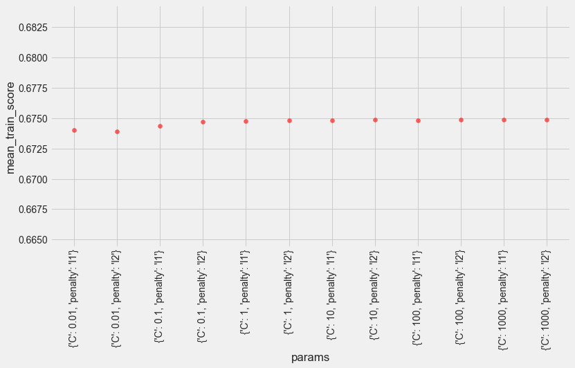

```python
print("Best parameters: {}".format(grid_search.best_params_))
print("Best cross-validation score: {:.5f}".format(grid_search.best_score_))
result[['params','mean_train_score']].values
plt.Figure(figsize=(10,3))
fig, ax = plt.subplots()
ax.scatter(result['params'].values,result['mean_train_score'].values, alpha=0.6,vmax=False,c='r')
ax.set_xlabel(xlabel='params')
ax.set_ylabel(ylabel='mean_train_score')
ax.set_xticklabels(result['params'].values,rotation=90)
```

```
[[ 0.6741155   0.6739263   0.67437477  0.67475317  0.67488631  0.67486528]
 [ 0.67487229  0.67485828  0.67480222  0.67485828  0.67485127  0.67485828]]
```

[figure not shown]

```python
scores = np.array(result.mean_test_score).reshape(2,6)
print(scores)
sns.heatmap(scores,cmap="viridis",yticklabels=param_grid['penalty'],annot=True,xticklabels=param_grid['C'],fmt='.5f')  #ylabel='penalty',xlabel='C',
```

```python
y_pred = grid_search.predict(xtest)
print("Test set accuracy score: {:.5f}".format(accuracy_score(ytest, y_pred)))
```

```
Test set accuracy score: 0.67499
```

```python
print(classification_report(ytest, y_pred))
```

```
             precision    recall  f1-score   support

          0       0.65      0.75      0.70     30414
          1       0.71      0.60      0.65     30747

avg / total       0.68      0.67      0.67     61161
```

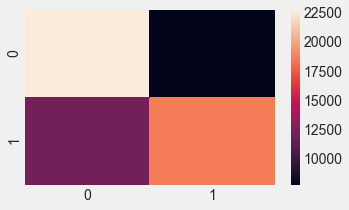

```python
m2 = confusion_matrix(ytest, y_pred)
plt.figure(figsize=(5,3))
sns.heatmap(m2)
```

```python
roc_auc2 = roc_auc_score(ytest, y_pred)
print("Area under the ROC curve : %f" % roc_auc2)
```

[output not shown]